# nhanes_metals

Nicole Comfort

12/17/2019

First, check whether you have the necessary packages installed and if not, install them.

# Background:

The National Health and Nutrition Examination Survey (NHANES) is a nationally-representative survey of the general, noninstutionalized US civilian population conducted by the National Center for Health Statistics. NHANES is a multi-stage sample completed in two-year cycles. Participants are chosen to represent the entire general U.S., but certain age groups and racial/ethnic groups are intentionally oversampled to ensure adequate power to analyze these populations.

Participants undergo thorough examination including demographic questionnaire, a 24-hr dietary recall, a clinical examination, and a laboratory examination. All NHANES protocols were approved by the National Center for Health Statistics institutional review board, and all participants gave written informed consent.

For more information on NHANES, view the Centers for Disease Control and Prevention (CDC) website: https://www.cdc.gov/nchs/nhanes/index.htm

### Note:

NHANES does not measure every environmental chemical in every participant. For some environmental chemicals, these measurements are only done on a subset of participant samples and there are special sub-weights that need to be used for analyzing these chemicals.

Here, we will explore the *unadjusted* levels of lead, cadmium, mercury, and manganese measured in blood of males versus females to examine if there is a sex difference in body burden of these chemicals.

We will conduct this analysis in one two-year survey cycle (2015/2016), *since combining weights across survey cycles is very complex.* See http://www.cdc.gov/nchs/tutorials/NHANES/SurveyDesign/Weighting/intro.htm for more information.

# Download NHANES Data and Clean

The data files must first be downloaded. They can be found and downloaded at the NHANES website: https://wwwn.cdc.gov/nchs/nhanes/continuousnhanes/default.aspx?BeginYear=2015

```r
# Load data

# Demographic files for 2015-2016
demo1516 <- read.xport("DEMO_I.XPT") %>%
  arrange(SEQN)
## Data documentation file: https://wwwn.cdc.gov/Nchs/Nhanes/2015-2016/DEMO_I.htm

# Laboratory blood Pb, Cd, Hg, Mn files for 2015-2016
cd1516 <- read.xport("PBCD_I.XPT") %>%
  arrange(SEQN)
## Data documentation file: https://wwwn.cdc.gov/Nchs/Nhanes/2015-2016/PBCD_I.htm
### Eligible Sample: All examined participants aged 1-11 years old, and a one-half sample from participants aged 12 years and older were eligible.

# Inorganic, Ethyl, Methyl Mercury for 2015-2016
hg1516 <- read.xport("IHGEM_I.XPT") %>%
  arrange(SEQN)
## Data documentation file: https://wwwn.cdc.gov/Nchs/Nhanes/2015-2016/IHGEM_I.htm
### Eligible Sample: All examined participants aged 1-11 years old, and a one-half sample from participants aged 12 years and older were eligible.

# Total Mercury in Urine for 2015-2016
uhg1516 <- read.xport("UHG_I.XPT") %>%
  arrange(SEQN)
## Data documentation file: https://wwwn.cdc.gov/Nchs/Nhanes/2015-2016/UHG_I.htm
### Eligible Sample: All examined participants aged 3 to 5 years were eligible and participants aged 6 years and older from a one-third subsample were eligible.
#### Note that this is different weighting scheme than for blood metals

## Arsenic
# Speciated urinary arsenics for 2015-2016
uas_sp <- read.xport("UAS_I.XPT") %>%
  arrange(SEQN)
## Data documentation file: https://wwwn.cdc.gov/Nchs/Nhanes/2015-2016/UAS_I.htm
### Eligible Sample: All examined participants aged 3 to 5 years were eligible and participants aged 6 years and older from a one-third subsample were eligible.

# Total urinary arsenic for 2015-2016
uas_t <- read.xport("UTAS_I.XPT") %>%
  arrange(SEQN)
## Data documentation file: https://wwwn.cdc.gov/Nchs/Nhanes/2015-2016/UTAS_I.htm
### Eligible Sample: All examined participants aged 3 to 5 years were eligible and participants aged 6 years and older from a one-third subsample were eligible.

# creatinine for 2015-2016 (for adjustment of urinary arsenic and urinary mercury)
creatinine <- read.xport("ALB_CR_I.XPT") %>%
  arrange(SEQN)
## Data documentation file: https://wwwn.cdc.gov/Nchs/Nhanes/2015-2016/ALB_CR_I.htm
### Eligible Sample: Examined participants aged 3 years and older were eligible.
```

## Blood Metals: Subset Data Cleaning and Evaluation

```r
# Blood metal dataframe

# Merge data to create one dataframe per year; then keep only the necessary variables:
nh1516 <- merge(demo1516, cd1516, by = "SEQN", all = TRUE)
nh1516 <- merge(nh1516, hg1516, by = c("SEQN", "WTSH2YR"), all = TRUE)
# later, exclude those who have WTSH2YR as "NA"

# double check that there aren't repeat columns renamed [col_name].x or [col_name].y

## Here is a list of variables we will need for our analysis:
# SEQN, SDDSRVYR, RIAGENDR, RIDAGEYR, RIDRETH1, WTMEC2YR, SDMVPSU, SDMVSTRA, WTSH2YR
# LBXBPB (blood lead), LBXBCD (blood cadmium),
# LBXBSE (blood selenium), LBXBMN (blood manganese)
# LBXTHG (blood total mercury), LBXIHG (blood inorganic mercury),
# LBXBGE (ethyl mercury), LBXBGM (methyl mercury)

# Retain only necessary variables:
nh1516_sub <-
  nh1516 %>%
  select(SEQN, SDDSRVYR, # unique identifier and survey year
         RIAGENDR, RIDAGEYR, RIDRETH1, # gender, age, race/ethnicity
         WTMEC2YR, SDMVPSU, SDMVSTRA, WTSH2YR, # weighting info
         LBDBPBLC, LBDBCDLC, LBDTHGLC, LBDBMNLC,  # comment codes for blood metals LOD
         LBDIHGLC, LBDBGELC, LBDBGMLC, # blood Hg comment codes for LOD
         LBXBPB, LBXBCD, LBXBMN, LBXTHG, LBXIHG, LBXBGE, LBXBGM) %>% # metals (exclude selenium for now)
  janitor::clean_names() %>%
  mutate(lbxohg = lbxthg - lbxihg) %>% # create new variable for organic mercury (total Hg - inorganic Hg)
  rename(sex = riagendr,
         age = ridageyr,
         race = ridreth1) %>%
  set_value_labels(                     # Label variable values
    sex = c("Male" = 1, "Female" = 2),
    race = c("Mexican American" = 1,
             "Other Hispanic" = 2,
             "NH White" = 3,
             "NH Black" = 4,
             "Other including multi" = 5)) %>%
  mutate_if(is.labelled, to_factor)  # Treat any labelled variables (e.g. sex) as factors


# Note to self: why are some organic mercury values (the variable I created) negative??
# PROBABLY BECAUSE THERE ARE A LOT OF IMPUTED VALUES SO THEY DON'T ADD UP

# later, plot mercury broken down as organic and inorganic, but also try breaking down organic to ethyl and methyl
# or Annie's recommendation was just to plot total and methyl?
```

Blood metals are measured in all participants aged 1-11 years old, and additionally in only a one-half subsample of participants 12 years and older.

Let’s find how many people are missing the weight value, indicating that they did not have their blood metals measured:

```r
# assess missingness of weights variable to see how many were eligible
# those that were eligible, i.e. all participants 1-11 and half of participants aged 12 and older will have a wtsh2yr value that is not equal to 0
nh1516_sub %>%
  count(is.na(wtsh2yr))
```

```
## # A tibble: 2 x 2
##   `is.na(wtsh2yr)`     n
##   <lgl>            <int>
## 1 FALSE             5815
## 2 TRUE              4156
```

```r
# The appropriate sample weights are provided in the variable WTSH2YR in this data file for all participants and should be used when analyzing these data.

# The analytes included in this dataset were measured for all examined participants aged 1-11 years, and in a one-half subsample of participants 12 years and older. For participants aged 1-11 years their WTSH2YR are equivalent to their MEC exam sample weights. These 1-11 years old participants have completed at least one physical exam component in the MEC; therefore, they all have an exam sample weight larger than “0,” regardless of their lab test results.

# For participants 12 years and older, special sample weights were created for the subsample. These special weights accounted for the additional probability of selection into the subsample, as well as the additional nonresponse to these lab tests. Therefore, if a participant 12 years and older was selected as part of the one-half subsample, but did not provide a blood specimen, he/she would have the sample weight value assigned as “0” in his/her record.

# so would including someone with weight 0 make a difference?? Can I just exclude them??

# drop rows missing the weight variable to arrive at the eligible subset
nh1516_sub <-
  nh1516_sub %>%
  drop_na(wtsh2yr) %>%
  filter(wtsh2yr != 0)
```

Of the 9,971 participants surveyed in 2015-2016, 5597 were eligible to have blood metals measured.

Check the percentage of imputed values for blood Pb, Cd, Mn, and total Hg:

```r
# The variable name ending in “LC” (ex., LBDBCDLC) indicates whether the result was below the limit of detection: the value “0” means that the result was at or above the limit of detection, “1” indicates that the result was below the limit of detection.

# For analytes with analytic results below the lower limit of detection (ex. LBDBCDLC=1), an imputed fill value was placed in the analyte results field. This value is the lower limit of detection divided by the square root of 2 (LLOD/sqrt[2]).

nh1516_sub %>%
  count(lbdbpblc == 1) # only 5 imputed values for Pb, < 1% imputed
```

```
## # A tibble: 3 x 2
##   `lbdbpblc == 1`     n
##   <lgl>           <int>
## 1 FALSE            4983
## 2 TRUE                5
## 3 NA                609
```

```r
nh1516_sub %>%
  count(lbdbcdlc == 1) # ouch, 23% < LOD for Cd, that's 34% if I include the 609 that have comment code "NA"
```

```
## # A tibble: 3 x 2
##   `lbdbcdlc == 1`     n
##   <lgl>           <int>
## 1 FALSE            3711
## 2 TRUE             1277
## 3 NA                609
```

```r
nh1516_sub %>%
  count(lbdthglc == 1) # same as for Cd, ~23% < LOD for total Hg
```

```
## # A tibble: 3 x 2
##   `lbdthglc == 1`     n
##   <lgl>           <int>
## 1 FALSE            3718
## 2 TRUE             1270
## 3 NA                609
```

```r
nh1516_sub %>%
  count(lbdbmnlc == 1) # 610 NA but otherwise no imputed values for Mn
```

```
## # A tibble: 2 x 2
##   `lbdbmnlc == 1`     n
##   <lgl>           <int>
## 1 FALSE            4987
## 2 NA                610
```

The LODs for Pb, Cd, total Hg, and Mn are 0.07 ug/dL, 0.1 ug/L, 0.28 ug/L, and 0.99 ug/L, respectively.

Virtually all participants had values > LOD for Pb and Mn, but 22% of participants had values < LOD for Cd and total Hg.

### Blood Metals: Missing Data

Let’s further evaluate missing data. Of those eligible, how many did not have blood metals measured?

```r
# of those eligible, how many are missing values of our metals of interest (Pb, Cd, Hg, Mn)?

## NOTE: According to the NHANES website, as a general rule, if 10% or less of your data for a variable are missing from your analytic dataset, it is usually acceptable to continue your analysis without further evaluation or adjustment
### However, if > 10% of the data for a variable are missing, you may need to determine whether the missing values are distributed equally across socio-demographic characteristics, and decide whether further imputation of missing values or use of adjusted weights are necessary

# for Pb
nh1516_sub %>%
  count(is.na(lbxbpb))
```

```
## # A tibble: 2 x 2
##   `is.na(lbxbpb)`     n
##   <lgl>           <int>
## 1 FALSE            4988
## 2 TRUE              609
```

```r
# 609, or 10.88% still missing data.... seems extremely high, should probably check to see whether missingness is at random or not

# for Cd
nh1516_sub %>%
  count(is.na(lbxbcd))
```

```
## # A tibble: 2 x 2
##   `is.na(lbxbcd)`     n
##   <lgl>           <int>
## 1 FALSE            4988
## 2 TRUE              609
```

```r
# 10.88% missing data

# for total Hg
nh1516_sub %>%
  count(is.na(lbxthg))
```

```
## # A tibble: 2 x 2
##   `is.na(lbxthg)`     n
##   <lgl>           <int>
## 1 FALSE            4988
## 2 TRUE              609
```

```r
# 10.88% missing data

# for Mn
nh1516_sub %>%
  count(is.na(lbxbmn))
```

```
## # A tibble: 2 x 2
##   `is.na(lbxbmn)`     n
##   <lgl>           <int>
## 1 FALSE            4987
## 2 TRUE              610
```

```r
# 10.89% missing data

# drop rows with missing values
nh1516_sub <-
  nh1516_sub %>%
  drop_na(lbxbpb, lbxbmn)
```

From our eligible subset, about 11% had missing values for blood metals Pb, Cd, Mn, and total Hg. Thus, after removing participants with missing values, we are left with 4987 for analysis.

## Inorganic, Ethyl, and Methyl Mercury: Subset Data Cleaning and Evaluation

### Inorganic, Ethyl, and Methyl Mercury: Missing Data

Because there were additional participants missing values of mercury (inorganic, ethyl, and methyl), we created a separate dataset, `hg1516`, for blood mercury. After retaining only complete cases, we are left with 4935 participants for mercury analysis.

```r
# The variable name ending in “LC” (ex., LBDBCDLC) indicates whether the result was below the limit of detection: the value “0” means that the result was at or above the limit of detection, “1” indicates that the result was below the limit of detection.

# For analytes with analytic results below the lower limit of detection (ex. LBDBCDLC=1), an imputed fill value was placed in the analyte results field. This value is the lower limit of detection divided by the square root of 2 (LLOD/sqrt[2]).

nh1516_sub %>%
  count(lbdihglc == 1) # for iHg, 75% of values are imputed (not including NAs)
```

```
## # A tibble: 3 x 2
##   `lbdihglc == 1`     n
##   <lgl>           <int>
## 1 FALSE             736
## 2 TRUE             4201
## 3 NA                 50
```

```r
nh1516_sub %>%
  count(lbdbgelc == 1) # for ethyl Hg, 87% of values are imputed (not including NAs)
```

```
## # A tibble: 3 x 2
##   `lbdbgelc == 1`     n
##   <lgl>           <int>
## 1 FALSE              53
## 2 TRUE             4882
## 3 NA                 52
```

```r
nh1516_sub %>%
  count(lbdbgmlc == 1) # for methyl Hg, 24% of values are imputed (not including NAs)
```

```
## # A tibble: 3 x 2
##   `lbdbgmlc == 1`     n
##   <lgl>           <int>
## 1 FALSE            3594
## 2 TRUE             1343
## 3 NA                 50
```

The LOD for inorganic, ethyl, and methyl mercury are 0.27 ug/L, 0.16 ug/L, and 0.12 ug/L, respectively.

## Urinary Mercury: Subset Data Cleaning and Evaluation

The concentration of total Hg in urine is a biomarker of exposure primarily to elemental and inorganic Hg, although some Hg in urine comes from de-methylation of methyl Hg in blood (Abe et al., 1995). Thus, examining total Hg in urine better reflects exposure to inorganic Hg.

NHANES 2015/2016 collected information on Hg in urine. We will analyze this data from NHANES 2015/2016 as well.

Urinary mercury is eligible to be measured in all participants aged 3 to 5 years and in a one-third subsample of participants aged 6 years and older.

### Urinary Mercury: Missing Data

Of the 9,971 participants surveyed in 2015-2016, 3231 were eligible to have urine mercury measured.

Furthermore, out of those eligible, about 4.6% were missing values for urinary mercury. After dropping those with values missing for urinary mercury and/or creatinine (needed for adjustment), we have 3077 participants remaining for analysis.

```r
# The variable name ending in “LC” (ex., LBDBCDLC) indicates whether the result was below the limit of detection: the value “0” means that the result was at or above the limit of detection, “1” indicates that the result was below the limit of detection.

# For analytes with analytic results below the lower limit of detection (ex. LBDBCDLC=1), an imputed fill value was placed in the analyte results field. This value is the lower limit of detection divided by the square root of 2 (LLOD/sqrt[2]).

uhg1516_sub %>%
  count(urduhglc == 1) # for urinary Hg, 58% of values are < LOD
```

```
## # A tibble: 2 x 2
##   `urduhglc == 1`     n
##   <lgl>           <int>
## 1 FALSE            1280
## 2 TRUE             1797
```

The LOD for urinary Hg is 0.13 ug/L. 58% of participants had values that were below the LOD. **Thus, urinary Hg in this dataset is not informative and we will not be analyzing it.**

## Urinary Arsenic: Subset Data Cleaning and Evaluation

```r
# Urinary arsenic dataframe

# Merge data to create one dataframe per year; then keep only the necessary variables:
uas1516 <- merge(demo1516, creatinine, by = "SEQN", all = TRUE)
uas1516 <- merge(uas1516, uas_sp, by = "SEQN", all = TRUE)
uas1516 <- merge(uas1516, uas_t, by = "SEQN", all = TRUE)

uas1516 <- uas1516 %>%
  mutate(WTSA2YR = WTSA2YR.x)

# later, exclude those who have WTSA2YR as "NA"

# Note that the total arsenic file, uas_t, did not have a comment code.
# The LOD for total urinary arsenic is 0.26 ug/L, so let's just count how many participants have values < 0.26

uas1516 %>%
  count(URXUAS < 0.26) # only two people have imputed values, so no need to worry!
```

```
## # A tibble: 3 x 2
##   `URXUAS < 0.26`     n
##   <lgl>           <int>
## 1 FALSE            3059
## 2 TRUE                2
## 3 NA               6910
```

```r
## Here is a list of variables we will need for our analysis:
# SEQN, SDDSRVYR, RIAGENDR, RIDAGEYR, RIDRETH1, WTMEC2YR, SDMVPSU, SDMVSTRA
# WTSA2YR (NEW WEIGHTING VARIABLE)
# URXUCR (creatinine, mg/dL)
# URXUAS3, URXUAS5, URXUAB, URXUAC, URXUDMA, URXUMMA (all in ug/L)
# URXUAS (total urine arsenic, ug/L)

# Data Cleaning to Create Urinary Hg Data Subset:
uas1516_sub <-
  uas1516 %>%
  select(SEQN, SDDSRVYR,
         RIAGENDR, RIDAGEYR, RIDRETH1,
         WTMEC2YR, SDMVPSU, SDMVSTRA, WTSA2YR,
         URDUA3LC, URDUA5LC, URDUABLC, URDUACLC, URDUDALC, URDUMMAL, # comment codes
         URXUCR, URXUAS3, URXUAS5, URXUAB, URXUAC, URXUDMA, URXUMMA, URXUAS) %>%
  janitor::clean_names() %>%
  mutate(urxucr = urxucr*10000) %>% # convert creatinine from mg/dL to ug/L
  #mutate(urxuas3 = urxuas3/urxucr, # did I adjust correctly??
         #urxuas5 = urxuas5/urxucr,
         #urxuab = urxuab/urxucr,
         #urxuac = urxuac/urxucr,
         #urxudma = urxudma/urxucr,
         #urxumma = urxumma/urxucr,
         #urxuas = urxuas/urxucr) %>% # urine arsenic adjusted for creatinine
  rename(sex = riagendr,
         age = ridageyr,
         race = ridreth1) %>%
  set_value_labels(                     # Label variable values
    sex = c("Male" = 1, "Female" = 2),
    race = c("Mexican American" = 1,
             "Other Hispanic" = 2,
             "NH White" = 3,
             "NH Black" = 4,
             "Other including multi" = 5)) %>%
  mutate_if(is.labelled, to_factor)  # Treat any labelled variables (e.g. sex) as factors
```

Urinary arsenic (total and speciated) is eligible to be measured in all participants aged 3 to 5 years and in a one-third subsample of participants aged 6 years and older.

### Urinary Arsenic: Missing Data

Of the 9,971 participants surveyed in 2015-2016, 3231 were eligible to have urine arsenic measured.

Furthermore, out of those eligible, 5.4% were missing values for total arsenic and DMA. After dropping those with values missing for urinary arsenic and/or creatinine (needed for adjustment), we have 3057 participants remaining for analysis.

```r
# The variable name ending in “LC” (ex., LBDBCDLC) indicates whether the result was below the limit of detection: the value “0” means that the result was at or above the limit of detection, “1” indicates that the result was below the limit of detection.

# For analytes with analytic results below the lower limit of detection (ex. LBDBCDLC=1), an imputed fill value was placed in the analyte results field. This value is the lower limit of detection divided by the square root of 2 (LLOD/sqrt[2]).

uas1516_sub %>%
  count(urdua3lc == 1) # 47% < LOD for arsenous acid
```

```
## # A tibble: 2 x 2
##   `urdua3lc == 1`     n
##   <lgl>           <int>
## 1 FALSE            1618
## 2 TRUE             1439
```

```r
uas1516_sub %>%
  count(urdua5lc == 1) # 97% < LOD for arsenic acid
```

```
## # A tibble: 2 x 2
##   `urdua5lc == 1`     n
##   <lgl>           <int>
## 1 FALSE              94
## 2 TRUE             2963
```

```r
uas1516_sub %>%
  count(urduablc == 1) # 60% < LOD for arsenobetaine
```

```
## # A tibble: 2 x 2
##   `urduablc == 1`     n
##   <lgl>           <int>
## 1 FALSE            1213
## 2 TRUE             1844
```

```r
uas1516_sub %>%
  count(urduaclc == 1) # 83% < LOD for arsenocholine
```

```
## # A tibble: 2 x 2
##   `urduaclc == 1`     n
##   <lgl>           <int>
## 1 FALSE             528
## 2 TRUE             2529
```

```r
uas1516_sub %>%
  count(urdudalc == 1) # 29% < LOD for dimethylarsinic acid (DMA)
```

```
## # A tibble: 2 x 2
##   `urdudalc == 1`     n
##   <lgl>           <int>
## 1 FALSE            2175
## 2 TRUE              882
```

```r
uas1516_sub %>%
  count(urdummal == 1) # 44% < LOD for monomethylarsonic acid (MMA)
```

```
## # A tibble: 2 x 2
##   `urdummal == 1`     n
##   <lgl>           <int>
## 1 FALSE            1698
## 2 TRUE             1359
```

The LOD for urinary total arsenic is 0.26 ug/L. Virtually all participants had a measurement of urinary total arsenic above the LOD. However, other than DMA, the percentage of participants with values < LOD were too high and so those species will not be analyzed. 29% of participants have values < LOD for DMA. This is a little on the high end, but we will still evaluate it.

### Total N’s

There were 9971 participants surveyed in the NHANES 2015-2016 cycle.

In our data subsets, there are:

- 4987 participants with Pb, Cd, Mn, and total Hg measured in blood,
- 4935 participants with inorganic, ethyl, and methyl Hg measured in blood,
- 3077 participants Hg measured in urine,
- 3057 participants with total and speciated arsenic measured in urine

for our analyses.

# Sample Weighting

Note that NHANES is designed to sample larger numbers of certain subgroups of particular public health interest (e.g. low income Americans, African Americans). Oversampling is done to increase the reliability and precision of estimates of health status indicators for these population subgroups. To account for this sampling design and these design features in our analysis, it is critical that we apply sample weights.

Continue data cleaning by applying appropriate sample weights, which will allow us to calculate unbiased estimates.

## Survey Weights

```
## Stratified 1 - level Cluster Sampling design (with replacement)
## With (30) clusters.
## svydesign(ids = ~sdmvpsu, strata = ~sdmvstra, weights = ~wtsh2yr,
##     nest = TRUE, data = nh1516_sub)
## Probabilities:
##      Min.   1st Qu.    Median      Mean   3rd Qu.      Max.
## 2.001e-06 1.558e-05 2.712e-05 3.949e-05 6.009e-05 1.882e-04
## Stratum Sizes:
##            119 120 121 122 123 124 125 126 127 128 129 130 131 132 133
## obs        205 362 350 285 309 289 319 388 327 361 355 387 413 398 239
## design.PSU   2   2   2   2   2   2   2   2   2   2   2   2   2   2   2
## actual.PSU   2   2   2   2   2   2   2   2   2   2   2   2   2   2   2
## Data variables:
##  [1] "seqn"     "sddsrvyr" "sex"      "age"      "race"     "wtmec2yr"
##  [7] "sdmvpsu"  "sdmvstra" "wtsh2yr"  "lbdbpblc" "lbdbcdlc" "lbdthglc"
## [13] "lbdbmnlc" "lbdihglc" "lbdbgelc" "lbdbgmlc" "lbxbpb"   "lbxbcd"
## [19] "lbxbmn"   "lbxthg"   "lbxihg"   "lbxbge"   "lbxbgm"   "lbxohg"
```

```
## Stratified 1 - level Cluster Sampling design (with replacement)
## With (30) clusters.
## svydesign(ids = ~sdmvpsu, strata = ~sdmvstra, weights = ~wtsh2yr,
##     nest = TRUE, data = hg1516_sub)
## Probabilities:
##      Min.   1st Qu.    Median      Mean   3rd Qu.      Max.
## 2.001e-06 1.548e-05 2.693e-05 3.914e-05 5.924e-05 1.882e-04
## Stratum Sizes:
##            119 120 121 122 123 124 125 126 127 128 129 130 131 132 133
## obs        205 359 348 275 307 287 318 385 326 357 350 387 407 390 234
## design.PSU   2   2   2   2   2   2   2   2   2   2   2   2   2   2   2
## actual.PSU   2   2   2   2   2   2   2   2   2   2   2   2   2   2   2
## Data variables:
##  [1] "seqn"     "sddsrvyr" "sex"      "age"      "race"     "wtmec2yr"
##  [7] "sdmvpsu"  "sdmvstra" "wtsh2yr"  "lbdbpblc" "lbdbcdlc" "lbdthglc"
## [13] "lbdbmnlc" "lbdihglc" "lbdbgelc" "lbdbgmlc" "lbxthg"   "lbxihg"
## [19] "lbxbge"   "lbxbgm"   "lbxohg"
```

```
## Stratified 1 - level Cluster Sampling design (with replacement)
## With (30) clusters.
## svydesign(ids = ~sdmvpsu, strata = ~sdmvstra, weights = ~wtsa2yr,
##     nest = TRUE, data = uhg1516_sub)
## Probabilities:
##      Min.   1st Qu.    Median      Mean   3rd Qu.      Max.
## 1.411e-06 9.376e-06 1.683e-05 2.390e-05 2.783e-05 1.526e-04
## Stratum Sizes:
##            119 120 121 122 123 124 125 126 127 128 129 130 131 132 133
## obs        134 216 208 178 186 190 205 251 204 206 216 235 252 247 149
## design.PSU   2   2   2   2   2   2   2   2   2   2   2   2   2   2   2
## actual.PSU   2   2   2   2   2   2   2   2   2   2   2   2   2   2   2
## Data variables:
##  [1] "seqn"       "sddsrvyr"   "sex"        "age"        "race"
##  [6] "urduhglc"   "wtmec2yr"   "sdmvpsu"    "sdmvstra"   "wtsa2yr"
## [11] "urxuhg"     "urxucr"     "cr_ng_ml"   "urxuhg_adj"
```

```
## Stratified 1 - level Cluster Sampling design (with replacement)
## With (30) clusters.
## svydesign(ids = ~sdmvpsu, strata = ~sdmvstra, weights = ~wtsa2yr,
##     nest = TRUE, data = uas1516_sub)
## Probabilities:
##      Min.   1st Qu.    Median      Mean   3rd Qu.      Max.
## 1.411e-06 9.376e-06 1.679e-05 2.381e-05 2.775e-05 1.526e-04
## Stratum Sizes:
##            119 120 121 122 123 124 125 126 127 128 129 130 131 132 133
## obs        133 215 208 176 185 189 205 248 203 204 215 232 250 245 149
## design.PSU   2   2   2   2   2   2   2   2   2   2   2   2   2   2   2
## actual.PSU   2   2   2   2   2   2   2   2   2   2   2   2   2   2   2
## Data variables:
##  [1] "seqn"     "sddsrvyr" "sex"      "age"      "race"     "wtmec2yr"
##  [7] "sdmvpsu"  "sdmvstra" "wtsa2yr"  "urdua3lc" "urdua5lc" "urduablc"
## [13] "urduaclc" "urdudalc" "urdummal" "urxucr"   "urxuas3"  "urxuas5"
## [19] "urxuab"   "urxuac"   "urxudma"  "urxumma"  "urxuas"
```

## Survey-Weighted Data Distributions

### Data Distribution: Blood Metals

After analyzing the data distributions for all variables we will consider, we decided we will log-transform each metal variable to create a more normal distribution.

### Data Distribution: Methyl Mercury

### Data Distribution: Urinary Mercury

{we are not analyzing urinary mercury, ignore}

### Data Distribution: Urinary Arsenic

## Descriptive Statistics

The log-transformed data looks better for Pb, Mn, as well as urinary Hg, total As, and DMA. **Thus, for these variables, we will use the log-transformed average for statistical tests, such as models and using the svyby function.**

Below are the geometric mean levels (and 95% CIs) of blood Pb, Cd, Mn, and Hg (total and meHg), as well as urinary total As and DMA in the US population (accounting for survey weights and design):

### Blood Pb

```r
### OVERALL

# Count number of males and females in this dataset
table(nh1516_sub$sex)
```

```
##
##   Male Female
##   2488   2499
```

```r
100*(svymean(~sex, blood.svy)) # weighted percentage of individuals by sex
```

```
##             mean     SE
## sexMale   48.802 0.0104
## sexFemale 51.198 0.0104
```

```r
#           mean     SE
# sexMale   48.802 0.0104
# sexFemale 51.198 0.0104

# overall population geometric mean Pb and 95% CI
pb_log_mean <-
  svymean(~log(lbxbpb),
          blood.svy)

## Geometric mean, overall blood Pb
exp(pb_log_mean)[1]
```

```
## log(lbxbpb)
##   0.8205086
```

```r
## 95% Confidence Intervals
# Geometric mean lower 95% confidence interval
exp(pb_log_mean[1] - 1.96 * sqrt(attr(pb_log_mean, "var")))
```

```
##             log(lbxbpb)
## log(lbxbpb)   0.7759487
```

```r
# Geometric mean upper 95% confidence interval
exp(pb_log_mean[1] + 1.96 * sqrt(attr(pb_log_mean, "var")))
```

```
##             log(lbxbpb)
## log(lbxbpb)   0.8676275
```

```r
### BY SEX

# svyby is the function that will compute summary statistics of continuous variables within your "svydesign", across a cateogrical variable. In this case, we want average log transformed blood metal values separately for males and females. We specify "svymean" at the end of the command line to tell the command that we want the average means.

# Pb by sex
svyby(~log(lbxbpb),
      by = ~sex,
      blood.svy,
      svymean,
      ci = TRUE)
```

```
##           sex log(lbxbpb)         se
## Male     Male  -0.0825263 0.02973103
## Female Female  -0.3077383 0.03711817
```

```r
# Males
# Geometric mean and 95% CI
exp(-0.0825263) # 0.9207872 ug/dL, geometric mean for males
```

```
## [1] 0.9207872
```

```r
exp(-0.0825263 - (1.96 * 0.02973103)) # lower 95% CI
```

```
## [1] 0.8686638
```

```r
exp(-0.0825263 + (1.96 * 0.02973103)) # upper 95% CI
```

```
## [1] 0.9760383
```

```r
# Females
# Geometric mean and 95% CI
exp(-0.3077383) # 0.7351077 ug/dL, geometric mean for females
```

```
## [1] 0.7351077
```

```r
exp(-0.3077383 - (1.96 * 0.03711817)) # lower 95% CI
```

```
## [1] 0.6835265
```

```r
exp(-0.3077383 + (1.96 * 0.03711817)) # upper 95% CI
```

```
## [1] 0.7905814
```

```r
# note that the exponentiated form of the mean of a log-transformed variable is the GEOMETRIC MEAN!

# To determine if this difference is statistically significnat, I do a t-test because I am comparing the mean of a continuous variable across two groups
tt_lbxbpb <-
  svyttest(log(lbxbpb)~sex,
           blood.svy)

tt_lbxbpb
```

```
##
##  Design-based t-test
##
## data:  log(lbxbpb) ~ sex
## t = -6.1359, df = 14, p-value = 2.58e-05
## alternative hypothesis: true difference in mean is not equal to 0
## 95 percent confidence interval:
##  -0.2971503 -0.1532736
## sample estimates:
## difference in mean
##          -0.225212
```

```r
# p-value = 2.58e-05, so the difference in mean blood Pb levels across males and females is significant

# note that lbxbpb is in the units ug/dL whereas the other blood metals are in ug/L
```

Graph the results:

```r
pb_sex_means <- read.csv("pb_sex_means.csv")
```

```r
pb_plot <-
pb_sex_means %>%
  ggplot(aes(x = Sex,
             y = geo_mean,
             fill = Sex)) +
  geom_point(aes(shape = Sex)) +
  geom_errorbar(aes(ymin = lower, # change for different metals
                    ymax = upper),
                    width = 0.2,
                    position = position_dodge(0.9)) +
  geom_signif(comparisons = list(c("Female", "Male")), annotations = "***") +
  labs(title = "Blood Pb Levels, Males vs Females", # edit labels for diff graphs
       x = "Sex",
       y = "Blood Pb (ug/dL)")
```

### Blood Cd

```r
# Count number of males and females in this dataset
table(nh1516_sub$sex)
```

```
##
##   Male Female
##   2488   2499
```

```r
100*(svymean(~sex, blood.svy)) # weighted percentage of individuals by sex
```

```
##             mean     SE
## sexMale   48.802 0.0104
## sexFemale 51.198 0.0104
```

```r
#           mean     SE
# sexMale   48.802 0.0104
# sexFemale 51.198 0 .0104

### OVERALL

# overall population geometric mean and 95% CI
cd_log_mean <-
  svymean(~log(lbxbcd), # ok to use log, or log10?? ASK
          blood.svy)

## Geometric mean, overall blood Cd
exp(cd_log_mean)[1]
```

```
## log(lbxbcd)
##   0.2380879
```

```r
## 95% Confidence Intervals
# Geometric mean lower 95% confidence interval
exp(cd_log_mean[1] - 1.96 * sqrt(attr(cd_log_mean, "var")))
```

```
##             log(lbxbcd)
## log(lbxbcd)   0.2254771
```

```r
# Geometric mean upper 95% confidence interval
exp(cd_log_mean[1] + 1.96 * sqrt(attr(cd_log_mean, "var")))
```

```
##             log(lbxbcd)
## log(lbxbcd)    0.251404
```

```r
### BY SEX

# Cd by sex
svyby(~log(lbxbcd),
      by = ~sex,
      blood.svy,
      svymean)
```

```
##           sex log(lbxbcd)         se
## Male     Male   -1.537352 0.03148460
## Female Female   -1.337665 0.03405788
```

```r
# Males
# Geometric mean and 95% CI
exp(-1.537352) # 0.2149495 ug/L, geometric mean for males
```

```
## [1] 0.2149495
```

```r
exp(-1.537352 - (1.96 * 0.03148460)) # lower 95% CI
```

```
## [1] 0.202086
```

```r
exp(-1.537352 + (1.96 * 0.03148460)) # upper 95% CI
```

```
## [1] 0.2286319
```

```r
# Females
# Geometric mean and 95% CI
exp(-1.337665) # 0.2624578 ug/L, geometric mean for females
```

```
## [1] 0.2624578
```

```r
exp(-1.337665 - (1.96 * 0.03405788)) # lower 95% CI
```

```
## [1] 0.2455098
```

```r
exp(-1.337665 + (1.96 * 0.03405788)) # upper 95% CI
```

```
## [1] 0.2805757
```

```r
# note that the exponentiated form of the mean of a log-transformed variable is the GEOMETRIC MEAN!

# To determine if this difference is statistically significnat, I do a t-test because I am comparing the mean of a continuous variable across two groups
tt_lbxbcd <-
  svyttest(log(lbxbcd)~sex,
           blood.svy)

tt_lbxbcd
```

```
##
##  Design-based t-test
##
## data:  log(lbxbcd) ~ sex
## t = 6.358, df = 14, p-value = 1.774e-05
## alternative hypothesis: true difference in mean is not equal to 0
## 95 percent confidence interval:
##  0.1381302 0.2612440
## sample estimates:
## difference in mean
##          0.1996871
```

```r
# p-value = 1.774e-05, so the difference in mean blood Cd levels across males and females is significant
```

Graph the results:

```r
cd_sex_means <- read.csv("cd_sex_means.csv")
```

```r
cd_plot <-
  cd_sex_means %>%
  ggplot(aes(x = Sex,
             y = geo_mean,
             fill = Sex)) +
  geom_point(aes(shape = Sex)) +
  geom_errorbar(aes(ymin = lower, # change for different metals
                    ymax = upper),
                    width = 0.2,
                    position = position_dodge(0.9)) +
  geom_signif(comparisons = list(c("Female", "Male")), annotations = "***") +
  labs(title = "Blood Cd Levels, Males vs Females", # edit labels for diff graphs
       x = "Sex",
       y = "Blood Cd (ug/L)")
```

### Blood Mn

```r
# Count number of males and females in this dataset
table(nh1516_sub$sex)
```

```
##
##   Male Female
##   2488   2499
```

```r
100*(svymean(~sex, blood.svy)) # weighted percentage of individuals by sex
```

```
##             mean     SE
## sexMale   48.802 0.0104
## sexFemale 51.198 0.0104
```

```r
#           mean     SE
# sexMale   48.802 0.0104
# sexFemale 51.198 0.0104

### OVERALL

# overall population geometric mean and 95% CI
mn_log_mean <-
  svymean(~log(lbxbmn),
          blood.svy)

## Geometric mean, overall blood Mn
exp(mn_log_mean)[1]
```

```
## log(lbxbmn)
##    9.589527
```

```r
## 95% Confidence Intervals
# Geometric mean lower 95% confidence interval
exp(mn_log_mean[1] - 1.96 * sqrt(attr(mn_log_mean, "var")))
```

```
##             log(lbxbmn)
## log(lbxbmn)    9.380852
```

```r
# Geometric mean upper 95% confidence interval
exp(mn_log_mean[1] + 1.96 * sqrt(attr(mn_log_mean, "var")))
```

```
##             log(lbxbmn)
## log(lbxbmn)    9.802845
```

```r
### BY SEX

# Mn by sex
svyby(~log(lbxbmn),
      by = ~sex,
      blood.svy,
      svymean)
```

```
##           sex log(lbxbmn)         se
## Male     Male    2.196282 0.01337830
## Female Female    2.322047 0.01144469
```

```r
# Males
# Geometric mean and 95% CI
exp(2.196282) # 8.991521 ug/L, geometric mean for males
```

```
## [1] 8.991521
```

```r
exp(2.196282 - (1.96 * 0.01337830)) # lower 95% CI
```

```
## [1] 8.758814
```

```r
exp(2.196282 + (1.96 * 0.01337830)) # upper 95% CI
```

```
## [1] 9.23041
```

```r
# Females
# Geometric mean and 95% CI
exp(2.322047) # 10.19653 ug/L, geometric mean for females
```

```
## [1] 10.19653
```

```r
exp(2.322047 - (1.96 * 0.01144469)) # lower 95% CI
```

```
## [1] 9.970347
```

```r
exp(2.322047 + (1.96 * 0.01144469)) # upper 95% CI
```

```
## [1] 10.42783
```

```r
# note that the exponentiated form of the mean of a log-transformed variable is the GEOMETRIC MEAN!

# To determine if this difference is statistically significnat, I do a t-test because I am comparing the mean of a continuous variable across two groups
tt_lbxbmn <-
  svyttest(log(lbxbmn)~sex,
           blood.svy)

tt_lbxbmn
```

```
##
##  Design-based t-test
##
## data:  log(lbxbmn) ~ sex
## t = 11.626, df = 14, p-value = 1.403e-08
## alternative hypothesis: true difference in mean is not equal to 0
## 95 percent confidence interval:
##  0.1045620 0.1469675
## sample estimates:
## difference in mean
##          0.1257648
```

```r
# p-value = 1.774e-05, so the difference in mean blood Cd levels across males and females is significant
```

Graph the results:

```r
mn_sex_means <- read.csv("mn_sex_means.csv")
```

```r
mn_plot <-
mn_sex_means %>%
  ggplot(aes(x = Sex,
             y = geo_mean,
             fill = Sex)) +
  geom_point(aes(shape = Sex)) +
  geom_errorbar(aes(ymin = lower, # change for different metals
                    ymax = upper),
                    width = 0.2,
                    position = position_dodge(0.9)) +
  geom_signif(comparisons = list(c("Female", "Male")), annotations = "***") +
  labs(title = "Blood Mn Levels, Males vs Females", # edit labels for diff graphs
       x = "Sex",
       y = "Blood Mn (ug/L)")
```

### Speciated Blood Hg

#### Total Hg

```r
### OVERALL

# Count number of males and females in this dataset
table(hg1516_sub$sex)
```

```
##
##   Male Female
##   2458   2477
```

```r
100*(svymean(~sex, blood.hg.svy)) # weighted percentage of individuals by sex
```

```
##             mean     SE
## sexMale   48.748 0.0104
## sexFemale 51.252 0.0104
```

```r
#            mean     SE
# sexMale   48.748 0.0104
# sexFemale 51.252 0.0104

# overall population geometric mean and 95% CI
total_hg_log_mean <-
  svymean(~log(lbxthg),
          blood.hg.svy)

## Geometric mean, total blood Hg
exp(total_hg_log_mean)[1]
```

```
## log(lbxthg)
##   0.6783779
```

```r
## 95% Confidence Intervals
# Geometric mean lower 95% confidence interval
exp(total_hg_log_mean[1] - 1.96 * sqrt(attr(total_hg_log_mean, "var")))
```

```
##             log(lbxthg)
## log(lbxthg)   0.6239191
```

```r
# Geometric mean upper 95% confidence interval
exp(total_hg_log_mean[1] + 1.96 * sqrt(attr(total_hg_log_mean, "var")))
```

```
##             log(lbxthg)
## log(lbxthg)   0.7375902
```

```r
### BY SEX

# total Hg by sex
svyby(~log(lbxthg),
      by = ~sex,
      blood.hg.svy,
      svymean)
```

```
##           sex log(lbxthg)         se
## Male     Male  -0.3880978 0.04220394
## Female Female  -0.3880060 0.05025774
```

```r
# Males
# Geometric mean and 95% CI
exp(-0.3880978) # 0.678346 ug/L, geometric mean for males
```

```
## [1] 0.678346
```

```r
exp(-0.3880978 - (1.96 * 0.04220394)) # lower 95% CI
```

```
## [1] 0.6244915
```

```r
exp(-0.3880978 + (1.96 * 0.04220394)) # upper 95% CI
```

```
## [1] 0.7368447
```

```r
# Females
# Geometric mean and 95% CI
exp(-0.3880060) # 0.6784083 ug/L, geometric mean for females
```

```
## [1] 0.6784083
```

```r
exp(-0.3880060 - (1.96 * 0.05025774)) # lower 95% CI
```

```
## [1] 0.6147675
```

```r
exp(-0.3880060 + (1.96 * 0.05025774)) # upper 95% CI
```

```
## [1] 0.7486372
```

```r
# note that the exponentiated form of the mean of a log-transformed variable is the GEOMETRIC MEAN!

# To determine if this difference is statistically significnat, I do a t-test because I am comparing the mean of a continuous variable across two groups
tt_lbxthg <-
  svyttest(log(lbxthg)~sex,
           blood.hg.svy)

tt_lbxthg
```

```
##
##  Design-based t-test
##
## data:  log(lbxthg) ~ sex
## t = 0.0024911, df = 14, p-value = 0.998
## alternative hypothesis: true difference in mean is not equal to 0
## 95 percent confidence interval:
##  -0.07219829  0.07238205
## sample estimates:
## difference in mean
##       9.187848e-05
```

```r
# p-value = 0.998, so the difference in mean blood total Hg levels across males and females is NOT significant
```

#### Methyl Mercury

```r
### OVERALL

# Count number of males and females in this dataset
table(hg1516_sub$sex)
```

```
##
##   Male Female
##   2458   2477
```

```r
100*(svymean(~sex, blood.hg.svy)) # weighted percentage of individuals by sex
```

```
##             mean     SE
## sexMale   48.748 0.0104
## sexFemale 51.252 0.0104
```

```r
#            mean     SE
# sexMale   48.748 0.0104
# sexFemale 51.252 0.0104

# overall population geometric mean and 95% CI
mehg_log_mean <-
  svymean(~log(lbxbgm),
          blood.hg.svy)

## Geometric mean, meHg
exp(mehg_log_mean)[1]
```

```
## log(lbxbgm)
##   0.4129753
```

```r
## 95% Confidence Intervals
# Geometric mean lower 95% confidence interval
exp(mehg_log_mean[1] - 1.96 * sqrt(attr(mehg_log_mean, "var")))
```

```
##             log(lbxbgm)
## log(lbxbgm)   0.3651942
```

```r
# Geometric mean upper 95% confidence interval
exp(mehg_log_mean[1] + 1.96 * sqrt(attr(mehg_log_mean, "var")))
```

```
##             log(lbxbgm)
## log(lbxbgm)    0.467008
```

```r
### BY SEX

# meHg by sex
svyby(~log(lbxbgm),
      by = ~sex,
      blood.hg.svy,
      svymean)
```

```
##           sex log(lbxbgm)         se
## Male     Male  -0.8482905 0.05858514
## Female Female  -0.9186819 0.07721073
```

```r
# Males
# Geometric mean and 95% CI
exp(-0.8482905) # 0.4281462 ug/L, geometric mean for males
```

```
## [1] 0.4281462
```

```r
exp(-0.8482905 - (1.96 * 0.05858514)) # lower 95% CI
```

```
## [1] 0.3817011
```

```r
exp(-0.8482905 + (1.96 * 0.05858514)) # upper 95% CI
```

```
## [1] 0.4802427
```

```r
# Females
# Geometric mean and 95% CI
exp(-0.9186819) # 0.3990447 ug/L, geometric mean for females
```

```
## [1] 0.3990447
```

```r
exp(-0.9186819 - (1.96 * 0.07721073)) # lower 95% CI
```

```
## [1] 0.3430034
```

```r
exp(-0.9186819 + (1.96 * 0.07721073)) # upper 95% CI
```

```
## [1] 0.4642422
```

```r
# note that the exponentiated form of the mean of a log-transformed variable is the GEOMETRIC MEAN!

# To determine if this difference is statistically significnat, I do a t-test because I am comparing the mean of a continuous variable across two groups
tt_lbxbgm <-
  svyttest(log(lbxbgm)~sex,
           blood.hg.svy)

tt_lbxbgm
```

```
##
##  Design-based t-test
##
## data:  log(lbxbgm) ~ sex
## t = -1.2357, df = 14, p-value = 0.2369
## alternative hypothesis: true difference in mean is not equal to 0
## 95 percent confidence interval:
##  -0.18203985  0.04125715
## sample estimates:
## difference in mean
##        -0.07039135
```

```r
# p-value = 0.2369, so the difference in mean blood meHg levels across males and females is NOT significant
```

Graph the results:

```r
# meHg

# upload dataset with the means and 95% CIs (pasted manually into a csv)
hg_sex_means <- read.csv("hg_sex_means.csv")
```

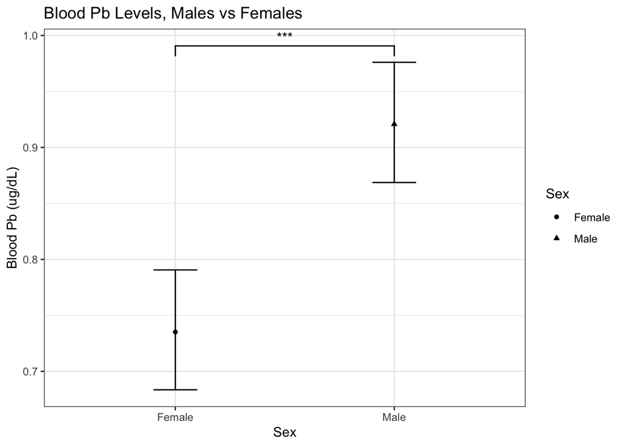

```r
# plot
hg_plot <-
hg_sex_means %>%
  ggplot(aes(x = Sex,
             y = geo_mean,
             fill = Type)) +
  geom_point(aes(color = Type,
                 shape = Sex),
                 position = "dodge") +
  geom_errorbar(aes(color = Type,
                    ymin = lower, # change for different metalas
                    ymax = upper),
                    width = 0.2) +
  geom_signif(comparisons = list(c("Female", "Male")), annotations = "NS") +
  labs(title = "Blood Hg Levels, Males vs Females", # edit labels for diff graphs
       x = "Sex",
       y = "Blood Hg (ug/L)")

pb_plot
```

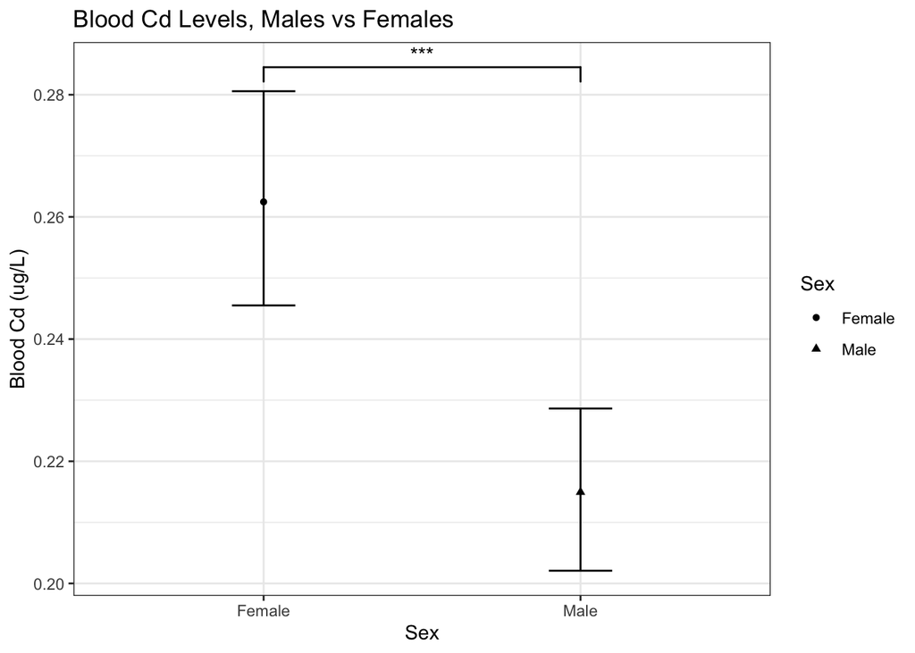

```r
cd_plot
```

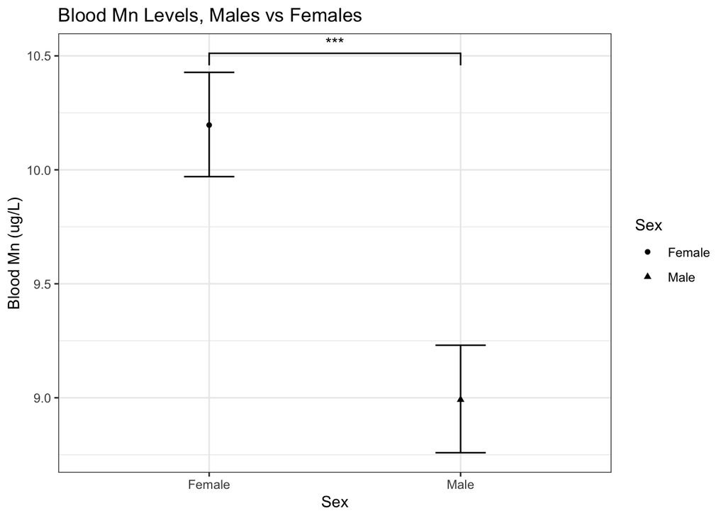

```r
mn_plot
```

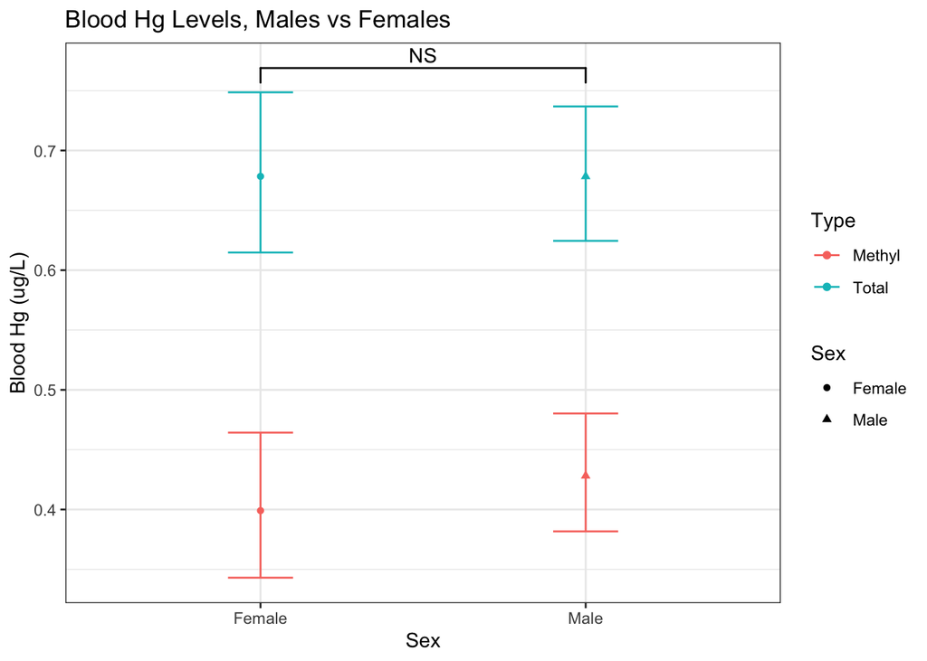

```r
hg_plot
```

### Urinary Hg

**The % of participants < LOD is too high to be meaningful!**

## Differences across age groups

The exposures and body burdens of these various metals often change over the life course, from childhood through elderly years. Do sex differences exist at certain windows across the life course that are otherwise masked when looking at mean metal levels averaged across all ages?

To explore this, we will create a new categorical variable, “life_stage,” that indicates whether an individual is in his or her child, adolescent, adult, or senior years.

**Question:** Accounting for survey design, what are the mean blood metal levels of 2015/2016 US males and females across childhood, adolescence, adulthood, and senior years?

We define “child” as age < 12 years, “adolescent” as age 12-21 years, “adult” as age 22-65 years, and “elderly” as age > 65 years.

```r
## create new life stage variable
nh1516_sub <-
  nh1516_sub %>%
  mutate(life_stage =
           ifelse(age < 12, "Child",
           ifelse(age %in% 12:21, "Adolescent",
           ifelse(age %in% 22:65, "Adult",
                  "Elderly")))) %>%
  mutate(life_stage = as.factor(life_stage))

# relevel the factors to be in chronological order of life stages
nh1516_sub$life_stage <- fct_relevel(nh1516_sub$life_stage, c("Child", "Adolescent", "Adult", "Elderly"))

# Re-set the survey design
# NOTE: We always have to re-set the survey design after we create any new variable.
nhanes.svy <- svydesign(ids = ~sdmvpsu,
                        strata = ~sdmvstra,
                        weights = ~wtsh2yr,
                        nest = TRUE,
                        data = nh1516_sub)

## Calculate geometric means across sex and life stages
svyby(~log(lbxbpb)+log(lbxbcd)+log(lbxthg)+log(lbxbmn), # continuous variable
      by = ~sex+life_stage, # groups
      nhanes.svy, # the ”svydesign” object
      svymean)  # the function you want
```

```
##                      sex life_stage log(lbxbpb) log(lbxbcd) log(lbxthg)
## Male.Child          Male      Child  -0.4079579  -2.3879116  -1.1020669
## Female.Child      Female      Child  -0.4819320  -2.3627154  -1.1058349
## Male.Adolescent     Male Adolescent  -0.5961827  -2.0140554  -0.8753927
## Female.Adolescent Female Adolescent  -0.9164565  -1.9180003  -0.9780576
## Male.Adult          Male      Adult  -0.0195910  -1.3695159  -0.1962730
## Female.Adult      Female      Adult  -0.3066270  -1.1415697  -0.1919991
## Male.Elderly        Male    Elderly   0.4666487  -1.0742895  -0.1607080
## Female.Elderly    Female    Elderly   0.2556720  -0.9823387  -0.2249962
##                   log(lbxbmn) se.log(lbxbpb) se.log(lbxbcd) se.log(lbxthg)
## Male.Child           2.323853     0.05420920     0.02031256     0.03507895
## Female.Child         2.392124     0.04470544     0.02313761     0.04401362
## Male.Adolescent      2.274922     0.02651436     0.04447693     0.06822641
## Female.Adolescent    2.405664     0.04140896     0.05147425     0.05103860
## Male.Adult           2.168011     0.03519421     0.04275419     0.04227269
## Female.Adult         2.328969     0.04102339     0.03224337     0.04984514
## Male.Elderly         2.135309     0.04561561     0.06492203     0.08475042
## Female.Elderly       2.189293     0.03872568     0.04117661     0.08425445
##                   se.log(lbxbmn)
## Male.Child            0.01786325
## Female.Child          0.01748702
## Male.Adolescent       0.01522021
## Female.Adolescent     0.03190488
## Male.Adult            0.01790147
## Female.Adult          0.01050378
## Male.Elderly          0.03037128
## Female.Elderly        0.02799830
```

```r
  svyby(~log(lbxbpb)+log(lbxbcd)+log(lbxthg)+log(lbxbmn),
      by = ~sex+life_stage,
      nhanes.svy,
      svymean) %>%
  kable() %>%
  kable_styling(bootstrap_options = c("striped", "hover"),
                full_width = F)
```

|  | sex | life_stage | log(lbxbpb) | log(lbxbcd) | log(lbxthg) | log(lbxbmn) | se.log(lbxbpb) | se.log(lbxbcd) | se.log(lbxthg) | se.log(lbxbmn) |
| --- | --- | --- | --- | --- | --- | --- | --- | --- | --- | --- |
| Male.Child | Male | Child | -0.4079579 | -2.3879116 | -1.1020669 | 2.323853 | 0.0542092 | 0.0203126 | 0.0350789 | 0.0178633 |
| Female.Child | Female | Child | -0.4819320 | -2.3627154 | -1.1058349 | 2.392124 | 0.0447054 | 0.0231376 | 0.0440136 | 0.0174870 |
| Male.Adolescent | Male | Adolescent | -0.5961827 | -2.0140554 | -0.8753927 | 2.274922 | 0.0265144 | 0.0444769 | 0.0682264 | 0.0152202 |
| Female.Adolescent | Female | Adolescent | -0.9164565 | -1.9180003 | -0.9780576 | 2.405664 | 0.0414090 | 0.0514742 | 0.0510386 | 0.0319049 |
| Male.Adult | Male | Adult | -0.0195910 | -1.3695159 | -0.1962730 | 2.168011 | 0.0351942 | 0.0427542 | 0.0422727 | 0.0179015 |
| Female.Adult | Female | Adult | -0.3066270 | -1.1415697 | -0.1919991 | 2.328969 | 0.0410234 | 0.0322434 | 0.0498451 | 0.0105038 |
| Male.Elderly | Male | Elderly | 0.4666487 | -1.0742895 | -0.1607080 | 2.135309 | 0.0456156 | 0.0649220 | 0.0847504 | 0.0303713 |
| Female.Elderly | Female | Elderly | 0.2556720 | -0.9823387 | -0.2249962 | 2.189293 | 0.0387257 | 0.0411766 | 0.0842544 | 0.0279983 |

```r
# put these means into a table and exponentiate them
  # the results are saved as the file, life_sex_means.XLSX

# Do the same for the hg1516_sub data (for methyl Hg)
  hg1516_sub <-
  hg1516_sub %>%
  mutate(life_stage =
           ifelse(age < 12, "Child",
           ifelse(age %in% 12:21, "Adolescent",
           ifelse(age %in% 22:65, "Adult",
                  "Elderly")))) %>%
  mutate(life_stage = as.factor(life_stage))

# relevel the factors to be in chronological order of life stages
hg1516_sub$life_stage <- fct_relevel(hg1516_sub$life_stage, c("Child", "Adolescent", "Adult", "Elderly"))

# Re-set the survey design
# NOTE: We always have to re-set the survey design after we create any new variable.
blood.hg.svy <- svydesign(ids = ~sdmvpsu,
                        strata = ~sdmvstra,
                        weights = ~wtsh2yr,
                        nest = TRUE,
                        data = hg1516_sub)

## Calculate geometric means across sex and life stages
svyby(~log(lbxbgm), # continuous variable
      by = ~sex+life_stage, # groups
      blood.hg.svy, # the ”svydesign” object
      svymean)  # the function you want
```

```
##                      sex life_stage log(lbxbgm)         se
## Male.Child          Male      Child  -1.8205867 0.05146394
## Female.Child      Female      Child  -1.8314426 0.05749732
## Male.Adolescent     Male Adolescent  -1.4725473 0.09120399
## Female.Adolescent Female Adolescent  -1.6157426 0.07954678
## Male.Adult          Male      Adult  -0.6050371 0.05805934
## Female.Adult      Female      Adult  -0.6960105 0.07996646
## Male.Elderly        Male    Elderly  -0.5192275 0.11135959
## Female.Elderly    Female    Elderly  -0.6509059 0.11228267
```

```r
  svyby(~log(lbxbgm),
      by = ~sex+life_stage,
      nhanes.svy,
      svymean) %>%
  kable() %>%
  kable_styling(bootstrap_options = c("striped", "hover"),
                full_width = F)
```

|  | sex | life_stage | log(lbxbgm) | se |
| --- | --- | --- | --- | --- |
| Male.Child | Male | Child | NA | NaN |
| Female.Child | Female | Child | NA | NaN |
| Male.Adolescent | Male | Adolescent | -1.4725473 | 0.0912040 |
| Female.Adolescent | Female | Adolescent | -1.6157426 | 0.0795468 |
| Male.Adult | Male | Adult | NA | NaN |
| Female.Adult | Female | Adult | NA | NaN |
| Male.Elderly | Male | Elderly | -0.5192275 | 0.1113596 |
| Female.Elderly | Female | Elderly | NA | NaN |

```r
# add this to the life means xlsx file (done)

# Ns per group
nh1516_sub %>%
  count(sex == "Female" & life_stage == "Elderly")
```

```
## # A tibble: 2 x 2
##   `sex == "Female" & life_stage == "Elderly"`     n
##   <lgl>                                       <int>
## 1 FALSE                                        4696
## 2 TRUE                                          291
```

```r
## Males
# N = 926 Male Child
# N = 309 Male Adolescent
# N = 966 Male Adult
# N = 287 Male Elderly
## Females
# N = 887 Female Child
# N = 307 Female Adolescent
# N = 1014 Female Adult
# N = 291 Female Elderly
```

Graph the results:

```r
# first, create a new dataset from the life_means_table data
# import data
life_means_data <-
  read_csv("life_sex_means.csv") %>%
  mutate(life_stage = as.factor(life_stage)) %>%
  select(Sex:upper)
```

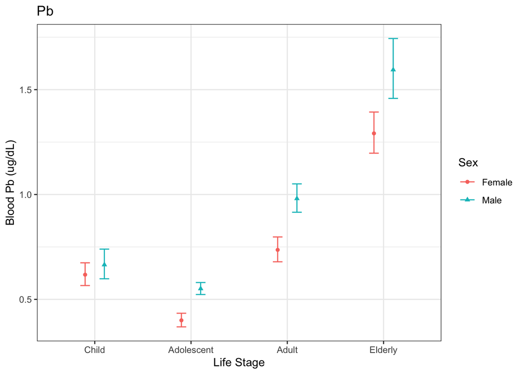

```r
life_means_data$life_stage <-
  factor(life_means_data$life_stage, levels = c("Child", "Adolescent", "Adult", "Elderly"))

# Lead
pb_life_plot <-
life_means_data %>%
  filter(metal == "lbxbpb") %>%
  ggplot(aes(x = life_stage,
             y = geo_mean,  # change for different metals
             fill = Sex)) +
  geom_point(aes(color = Sex,
                 shape = Sex),
                 position = position_dodge(0.4)) +
  geom_errorbar(aes(color = Sex,
                    ymin = lower, # change for different metalas
                    ymax = upper),
                    width = 0.2,
                    position = position_dodge(0.4)) +
  #geom_signif(comparisons = list(c("Female", "Male"))) +
  labs(title = "Pb", # edit labels for diff graphs
       x = "Life Stage",
       y = "Blood Pb (ug/dL)")

# Cd
cd_life_plot <-
life_means_data %>%
  filter(metal == "lbxbcd") %>%
  ggplot(aes(x = life_stage,
             y = geo_mean,  # change for different metals
             fill = Sex)) +
  geom_point(aes(color = Sex,
                 shape = Sex),
                 position = position_dodge(0.4)) +
  geom_errorbar(aes(color = Sex,
                    ymin = lower, # change for different metalas
                    ymax = upper),
                    width = 0.2,
                    position = position_dodge(0.4)) +
  #geom_signif(comparisons = list(c("Female", "Male"))) +
  labs(title = "Cd", # edit labels for diff graphs
       x = "Life Stage",
       y = "Blood Cd (ug/L)")

# Mn
mn_life_plot <-
life_means_data %>%
  filter(metal == "lbxbmn") %>%
  ggplot(aes(x = life_stage,
             y = geo_mean,  # change for different metals
             fill = Sex)) +
  geom_point(aes(color = Sex,
                 shape = Sex),
                 position = position_dodge(0.4)) +
  geom_errorbar(aes(color = Sex,
                    ymin = lower, # change for different metalas
                    ymax = upper),
                    width = 0.2,
                    position = position_dodge(0.4)) +
  #geom_signif(comparisons = list(c("Female", "Male"))) +
  labs(title = "Mn", # edit labels for diff graphs
       x = "Life Stage",
       y = "Blood Mn (ug/L)")

# Total Hg
hg_life_plot <-
life_means_data %>%
  filter(metal == "lbxthg") %>%
  ggplot(aes(x = life_stage,
             y = geo_mean,  # change for different metals
             fill = Sex)) +
  geom_point(aes(color = Sex,
                 shape = Sex),
                 position = position_dodge(0.4)) +
  geom_errorbar(aes(color = Sex,
                    ymin = lower, # change for different metalas
                    ymax = upper),
                    width = 0.2,
                    position = position_dodge(0.4)) +
  #geom_signif(comparisons = list(c("Female", "Male"))) +
  labs(title = "Hg (Total)", # edit labels for diff graphs
       x = "Life Stage",
       y = "Total Blood Hg (ug/L)")

# MeHg
mehg_life_plot <-
life_means_data %>%
  na.omit() %>%
  filter(metal == "lbxbgm") %>%
  ggplot(aes(x = life_stage,
             y = geo_mean,  # change for different metals
             fill = Sex)) +
  geom_point(aes(color = Sex,
                 shape = Sex),
                 position = position_dodge(0.4)) +
  geom_errorbar(aes(color = Sex,
                    ymin = lower, # change for different metals
                    ymax = upper),
                    width = 0.2,
                    position = position_dodge(0.4)) +
  labs(title = "MeHg", # edit labels for diff graphs
       x = "Life Stage",
       y = "Blood MeHg (ug/L)")

pb_life_plot
```

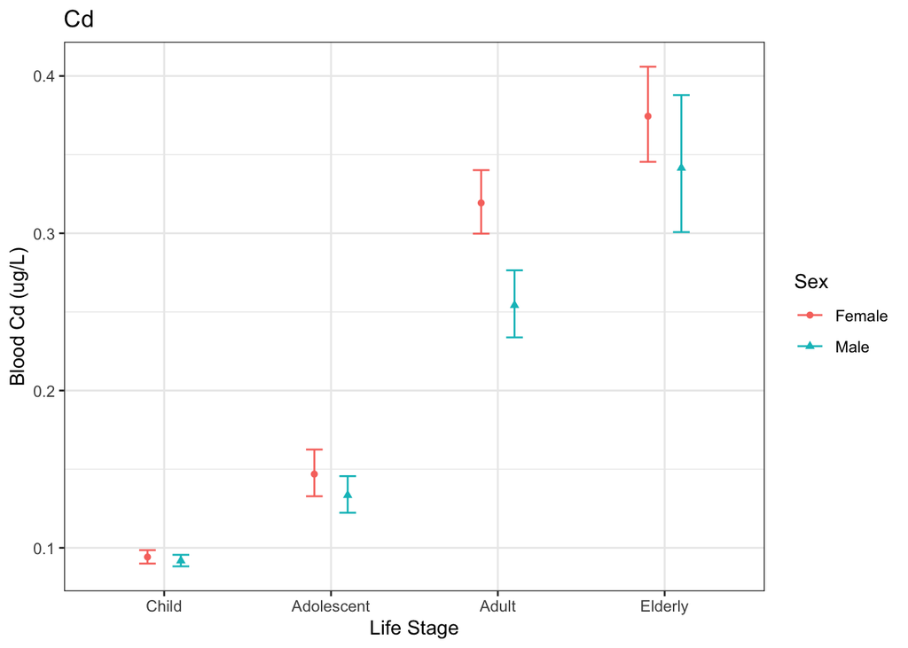

```r
cd_life_plot
```

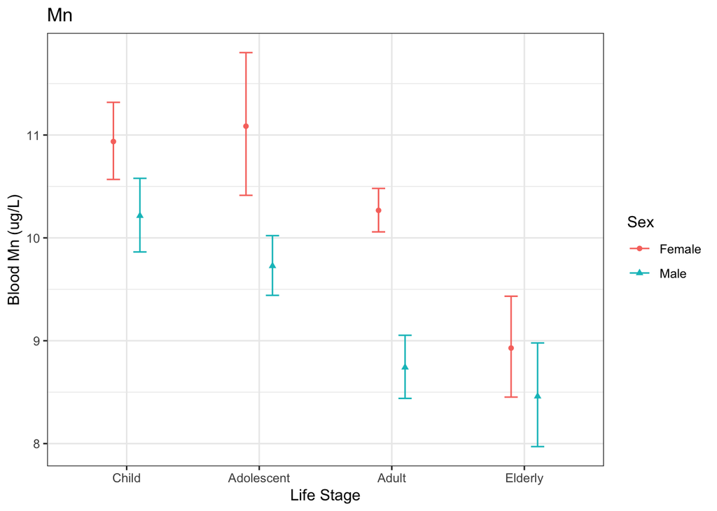

```r
mn_life_plot
```

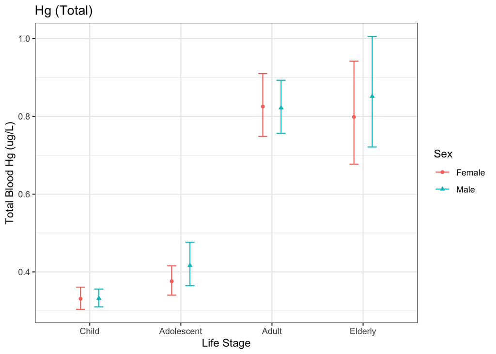

```r
hg_life_plot
```

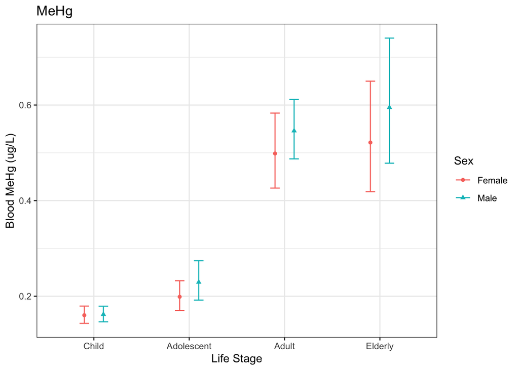

```r
mehg_life_plot
```

Are these differences seen across sex and age group significant?

```r
# use ANOVA because I am comparing the mean of a continuous variable across two categorical variables (sex and age group)

# Pb
model1 <- svyglm(log(lbxbpb)~life_stage+sex,
                 design = nhanes.svy)

summary(model1) # gives overall p value
```

```
##
## Call:
## svyglm(formula = log(lbxbpb) ~ life_stage + sex, design = nhanes.svy)
##
## Survey design:
## svydesign(ids = ~sdmvpsu, strata = ~sdmvstra, weights = ~wtsh2yr,
##     nest = TRUE, data = nh1516_sub)
##
## Coefficients:
##                      Estimate Std. Error t value Pr(>|t|)
## (Intercept)          -0.31928    0.05247  -6.085 7.90e-05 ***
## life_stageAdolescent -0.30807    0.04107  -7.500 1.20e-05 ***
## life_stageAdult       0.28475    0.05240   5.434 0.000206 ***
## life_stageElderly     0.81326    0.05558  14.633 1.48e-08 ***
## sexFemale            -0.25732    0.02795  -9.207 1.68e-06 ***
## ---
## Signif. codes:  0 '***' 0.001 '**' 0.01 '*' 0.05 '.' 0.1 ' ' 1
##
## (Dispersion parameter for gaussian family taken to be 0.4045795)
##
## Number of Fisher Scoring iterations: 2
```

```r
anova(model1,
      type = "II")
```

```
## Anova table:  (Rao-Scott LRT)
## svyglm(formula = log(lbxbpb) ~ life_stage, design = nhanes.svy)
##              stats      DEff        df ddf         p
## life_stage 441.239   0.91347   3.00000  12 1.837e-09 ***
## sex         82.164   0.96928   1.00000  11 1.867e-06 ***
## ---
## Signif. codes:  0 '***' 0.001 '**' 0.01 '*' 0.05 '.' 0.1 ' ' 1
```

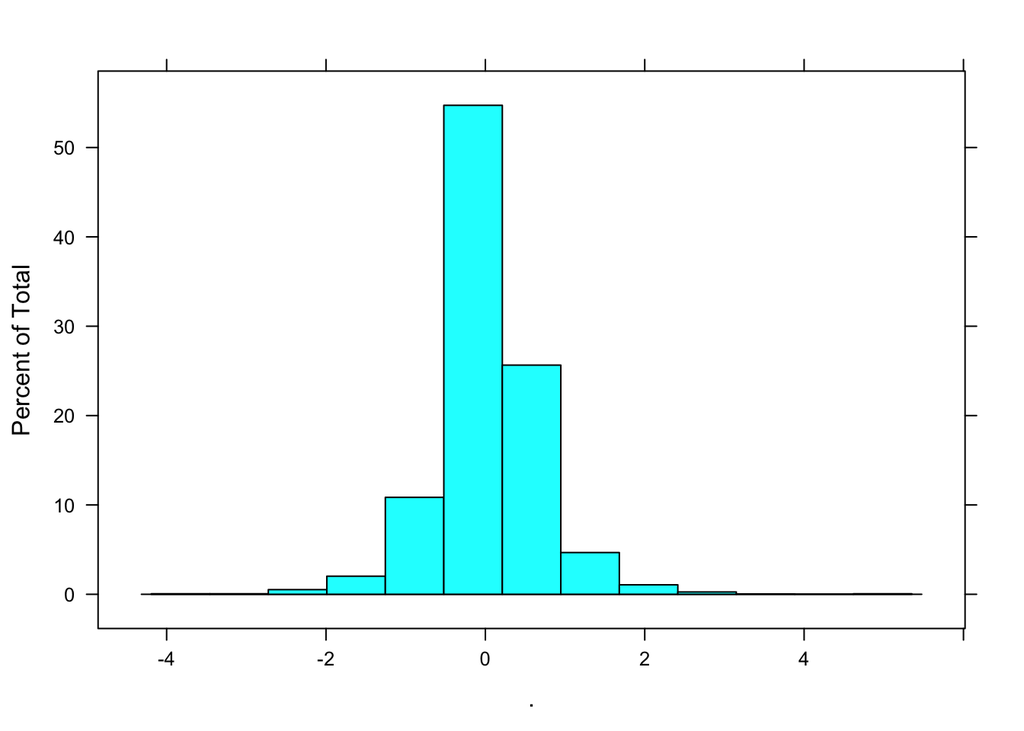

```r
residuals(model1) %>%
  histogram()
```

```r
# Cd
model2 <- svyglm(log(lbxbcd)~life_stage+sex,
                 design = nhanes.svy)

summary(model2)
```

```
##
## Call:
## svyglm(formula = log(lbxbcd) ~ life_stage + sex, design = nhanes.svy)
##
## Survey design:
## svydesign(ids = ~sdmvpsu, strata = ~sdmvstra, weights = ~wtsh2yr,
##     nest = TRUE, data = nh1516_sub)
##
## Coefficients:
##                      Estimate Std. Error  t value Pr(>|t|)
## (Intercept)          -2.45790    0.02411 -101.952  < 2e-16 ***
## life_stageAdolescent  0.40729    0.03557   11.451 1.88e-07 ***
## life_stageAdult       1.11756    0.02676   41.759 1.81e-13 ***
## life_stageElderly     1.33764    0.04160   32.153 3.14e-12 ***
## sexFemale             0.16989    0.02903    5.852 0.000111 ***
## ---
## Signif. codes:  0 '***' 0.001 '**' 0.01 '*' 0.05 '.' 0.1 ' ' 1
##
## (Dispersion parameter for gaussian family taken to be 0.561445)
##
## Number of Fisher Scoring iterations: 2
```

```r
anova(model2)
```

```
## Anova table:  (Rao-Scott LRT)
## svyglm(formula = log(lbxbcd) ~ life_stage, design = nhanes.svy)
##              stats      DEff        df ddf         p
## life_stage 886.070   0.53464   3.00000  12 9.106e-13 ***
## sex         35.815   1.04587   1.00000  11 0.0001211 ***
## ---
## Signif. codes:  0 '***' 0.001 '**' 0.01 '*' 0.05 '.' 0.1 ' ' 1
```

```r
# Mn
model3 <- svyglm(log(lbxbmn)~life_stage+sex,
                 design = nhanes.svy)

summary(model3)
```

```
##
## Call:
## svyglm(formula = log(lbxbmn) ~ life_stage + sex, design = nhanes.svy)
##
## Survey design:
## svydesign(ids = ~sdmvpsu, strata = ~sdmvstra, weights = ~wtsh2yr,
##     nest = TRUE, data = nh1516_sub)
##
## Coefficients:
##                      Estimate Std. Error t value Pr(>|t|)
## (Intercept)           2.29300    0.01781 128.755  < 2e-16 ***
## life_stageAdolescent -0.01873    0.02583  -0.725    0.483
## life_stageAdult      -0.11046    0.01520  -7.269 1.60e-05 ***
## life_stageElderly    -0.20374    0.03136  -6.496 4.45e-05 ***
## sexFemale             0.13207    0.01088  12.144 1.03e-07 ***
## ---
## Signif. codes:  0 '***' 0.001 '**' 0.01 '*' 0.05 '.' 0.1 ' ' 1
##
## (Dispersion parameter for gaussian family taken to be 0.1046821)
##
## Number of Fisher Scoring iterations: 2
```

```r
anova(model3)
```

```
## Anova table:  (Rao-Scott LRT)
## svyglm(formula = log(lbxbmn) ~ life_stage, design = nhanes.svy)
##             stats     DEff       df ddf         p
## life_stage 15.670  0.20624  3.00000  12 9.871e-05 ***
## sex        21.643  0.14676  1.00000  11 1.155e-07 ***
## ---
## Signif. codes:  0 '***' 0.001 '**' 0.01 '*' 0.05 '.' 0.1 ' ' 1
```

```r
# Total Hg
model4 <- svyglm(log(lbxthg)~life_stage+sex,
                 design = blood.hg.svy)

summary(model4)
```

```
##
## Call:
## svyglm(formula = log(lbxthg) ~ life_stage + sex, design = blood.hg.svy)
##
## Survey design:
## svydesign(ids = ~sdmvpsu, strata = ~sdmvstra, weights = ~wtsh2yr,
##     nest = TRUE, data = hg1516_sub)
##
## Coefficients:
##                      Estimate Std. Error t value Pr(>|t|)
## (Intercept)          -1.09779    0.02997 -36.627 7.57e-13 ***
## life_stageAdolescent  0.17993    0.05459   3.296  0.00713 **
## life_stageAdult       0.91058    0.05014  18.160 1.50e-09 ***
## life_stageElderly     0.90886    0.08130  11.178 2.40e-07 ***
## sexFemale            -0.01686    0.03925  -0.430  0.67585
## ---
## Signif. codes:  0 '***' 0.001 '**' 0.01 '*' 0.05 '.' 0.1 ' ' 1
##
## (Dispersion parameter for gaussian family taken to be 0.8213677)
##
## Number of Fisher Scoring iterations: 2
```

```r
anova(model4)
```

```
## Anova table:  (Rao-Scott LRT)
## svyglm(formula = log(lbxthg) ~ life_stage, design = blood.hg.svy)
##               stats      DEff        df ddf         p
## life_stage 596.4860   1.23950   3.00000  12 2.058e-09 ***
## sex          0.3491   1.89214   1.00000  11    0.6705
## ---
## Signif. codes:  0 '***' 0.001 '**' 0.01 '*' 0.05 '.' 0.1 ' ' 1
```

```r
# MeHg
model5 <- svyglm(log(lbxbgm)~life_stage+sex,
                 design = blood.hg.svy)

summary(model5)
```

```
##
## Call:
## svyglm(formula = log(lbxbgm) ~ life_stage + sex, design = blood.hg.svy)
##
## Survey design:
## svydesign(ids = ~sdmvpsu, strata = ~sdmvstra, weights = ~wtsh2yr,
##     nest = TRUE, data = hg1516_sub)
##
## Coefficients:
##                      Estimate Std. Error t value Pr(>|t|)
## (Intercept)          -1.77987    0.03870 -45.990 6.28e-14 ***
## life_stageAdolescent  0.28329    0.06360   4.454 0.000971 ***
## life_stageAdult       1.17668    0.05724  20.556 3.98e-10 ***
## life_stageElderly     1.23883    0.09396  13.185 4.39e-08 ***
## sexFemale            -0.09465    0.05995  -1.579 0.142653
## ---
## Signif. codes:  0 '***' 0.001 '**' 0.01 '*' 0.05 '.' 0.1 ' ' 1
##
## (Dispersion parameter for gaussian family taken to be 1.430152)
##
## Number of Fisher Scoring iterations: 2
```

```r
anova(model5)
```

```
## Anova table:  (Rao-Scott LRT)
## svyglm(formula = log(lbxbgm) ~ life_stage, design = blood.hg.svy)
##              stats     DEff       df ddf         p
## life_stage 972.594   1.7698   3.0000  12 1.088e-09 ***
## sex         11.002   4.4132   1.0000  11    0.1461
## ---
## Signif. codes:  0 '***' 0.001 '**' 0.01 '*' 0.05 '.' 0.1 ' ' 1
```

```r
#anova(model1, model2)
#anova(model1, model2, method="Wald")
```

```r
# Lead, Ages 1-2

## Q: How can I calculate and graph the mean if the stratum has only one PSU at stage 1??
# A: Use "lonely adjust" and note that this may not be representative of the true population mean
## lead in ages 1-2
nh1516_young <-
  nh1516_sub %>%
  filter(age == 1 | age == 2)

nhanes.svy.young <- svydesign(ids = ~sdmvpsu, # cluster IDs
                        strata = ~sdmvstra, # strata IDs
                        weights = ~wtsh2yr, # individual weights, subsample descriptions and weights are found in the specific datafiles downloaded from NHANES website
                        nest = TRUE,
                        data = nh1516_young) # call the dataframe

svyby(~log(lbxbpb), # continuous variable
      by = ~sex, # groups
      nhanes.svy.young, # the ”svydesign” object
      svymean, # the function you want %>%
      ci = TRUE)
```

```
##           sex log(lbxbpb)         se
## Male     Male -0.08252317 0.08196704
## Female Female -0.13669767 0.05977107
```

```r
# Note that in the setup chunk, the survey options is set so that survey.lonely.psu = "adjust"
# this means that even though this data only comes from one PSU, the code does not give an error
# we use "adjust" to center the stratum at the population mean rather than the stratum mean
# the data for the single-PSU stratum are centered at the sample grand mean rather than the stratum mean. This is conservative.

tt_pb_young <-
  svyttest(log(lbxbpb)~sex,
           nhanes.svy.young)

tt_pb_young
```

```
##
##  Design-based t-test
##
## data:  log(lbxbpb) ~ sex
## t = -0.69764, df = 13, p-value = 0.4977
## alternative hypothesis: true difference in mean is not equal to 0
## 95 percent confidence interval:
##  -0.20637405  0.09802506
## sample estimates:
## difference in mean
##         -0.0541745
```

```r
young_pb_means <- read_csv("young_pb_means.csv")
```

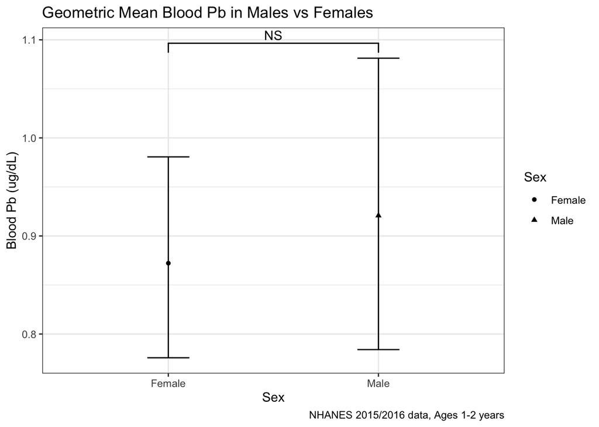

```r
young_pb_means %>%
  ggplot(aes(x = Sex,
             y = lbxbpb,
             fill = Sex)) +
  geom_point(aes(shape = Sex)) +
  geom_errorbar(aes(ymin = lower, # change for different metals
                    ymax = upper),
                    width = 0.2,
                    position = position_dodge(0.9)) +
  geom_signif(comparisons = list(c("Female", "Male")), annotations = "NS") +
  labs(title = "Geometric Mean Blood Pb in Males vs Females", # edit labels for diff graphs
       x = "Sex",
       y = "Blood Pb (ug/dL)",
       caption = "NHANES 2015/2016 data, Ages 1-2 years")
```

```r
# p-value = 0.4977 so the difference between males and females at this young age is not apparent, although this was just from one PSU so may not be representative of this segment of the population
```

–Extra Stuff–

### Urinary Total As and DMA

**Need to adjust for arsenobetaine. Or just plot arsenobetaine and DMA? See Annie’s methods.**

```r
# AsB is found in seafood and considered to be relatively nontoxic (Choi et al., 2010, Heinrich-Ramm et al., 2002). Therefore, we uses a residual method to provide an estimate of arsenic exposure that minimizes the potential influence of seafood arsenic intake (Jones et al., 2016). This approach yields a calibrated urinary biomarker by regressing DMA by AsB and extracting the model residuals [e.g. ln(DMAi)= β0 + β1 ×ln(arsenobetainei)+ εi]. Additionally, we conducted a sensitivity analysis that used a residual adjusted total urinary arsenic [e.g. ln(Total As)= β0 + β1 ×ln(arsenobetainei)+ εi]. Finally, we used data from 24-h dietary recall to create a variable of recent seafood consumption (yes/no) (Welch et al., 2018). Urinary creatinine was measured by an enzymatic method by a Roche/Hitachi Modular P Chemistry Analyzer. Urinary creatinine was used as a separate independent variable to adjust for differences in urine dilution (Barr et al., 2005).

# Urinary concentrations of iAs, MMA and DMA from exposure to iAs were obtained by regressing the measured concentrations of iAs, MMA, and DMA on arsenobetaine concentrations using a log-log regression model as follows: log(arsenicali)=β0+β1×log(arsenobetainei)+εi,for i in 1,…,N, where arsenical corresponds to iAs, MMA, or DMA, β0 and β1 correspond to the intercept and slope coefficients, and εi represents the residuals in the ith individual of N total individuals.

# for Total Arsenic, adjusted for arsenobetaine and creatinine
arsenic_model <- svyglm(log(urxuas)~urxucr+log(urxuab),
                 arsenic.svy)
# should I also include independent variables for age, sex, and race/ethnicity? What about BMI?

summary(arsenic_model)
```

```
##
## Call:
## svyglm(formula = log(urxuas) ~ urxucr + log(urxuab), design = arsenic.svy)
##
## Survey design:
## svydesign(ids = ~sdmvpsu, strata = ~sdmvstra, weights = ~wtsa2yr,
##     nest = TRUE, data = uas1516_sub)
##
## Coefficients:
##              Estimate Std. Error t value Pr(>|t|)
## (Intercept) 8.256e-01  3.295e-02   25.05 2.18e-12 ***
## urxucr      4.739e-07  2.981e-08   15.90 6.74e-10 ***
## log(urxuab) 6.615e-01  1.195e-02   55.35  < 2e-16 ***
## ---
## Signif. codes:  0 '***' 0.001 '**' 0.01 '*' 0.05 '.' 0.1 ' ' 1
##
## (Dispersion parameter for gaussian family taken to be 0.2924256)
##
## Number of Fisher Scoring iterations: 2
```

```r
# for DMA, adjusted for arsenobetaine and creatinine
dma_model <- svyglm(log(urxudma)~urxucr+log(urxuab),
                 arsenic.svy)
# should I also include independent variables for age, sex, and race/ethnicity? What about BMI?

summary(dma_model)
```

```
##
## Call:
## svyglm(formula = log(urxudma) ~ urxucr + log(urxuab), design = arsenic.svy)
##
## Survey design:
## svydesign(ids = ~sdmvpsu, strata = ~sdmvstra, weights = ~wtsa2yr,
##     nest = TRUE, data = uas1516_sub)
##
## Coefficients:
##              Estimate Std. Error t value Pr(>|t|)
## (Intercept) 4.698e-01  3.253e-02   14.44 2.20e-09 ***
## urxucr      4.282e-07  3.010e-08   14.23 2.65e-09 ***
## log(urxuab) 2.390e-01  1.907e-02   12.53 1.24e-08 ***
## ---
## Signif. codes:  0 '***' 0.001 '**' 0.01 '*' 0.05 '.' 0.1 ' ' 1
##
## (Dispersion parameter for gaussian family taken to be 0.336797)
##
## Number of Fisher Scoring iterations: 2
```

```r
# extract the residuals
as_adj <- residuals(arsenic_model)
dma_adj <- residuals(dma_model)
# now, add the mean levels of the corresponding arsenic species (iAs or DMA estimated from participants with low arsenobetaine (<1 µg/L)) to the residuals

# calculate mean iAs and DMA among participants with low arsenobetaine
low_urxuab <-
  uas1516_sub %>%
  filter(urxuab < 1.0)

mean(low_urxuab$urxuas) # add the mean or geometric mean?
```

```
## [1] 4.663655
```

```r
# 4.663655
mean(low_urxuab$urxudma)
```

```
## [1] 3.217484
```

```r
# 3.217484

# add these means to the residuals
uas_total <- as_adj + 4.663655
uas_dma <- dma_adj + 3.217484

# the calibrated biomarkers for total arsenic and DMA should no longer reflect organic arsenicals from seafood
```